# INFORME SOBRE DESPOBLACIÓN EN LA COMUNIDAD VALENCIANA

Tomàs Ferrandis Moscardó

2023-12-31

# 1. ANTECEDENTES

Se pretende elaborar un informe sobre el fenómeno de la despoblación en la comunidad Valenciana desde el punto de vista del Derecho Administrativo. Más que una extensa descripción del fenómeno o de sus causas, nos interesará centrarnos en cómo se ha afrontado el problema desde el ámbito administrativo. Nuestro trabajo pondrá el foco en la administración autonómica considerando sus competencias y, consecuentemente, las posibilidades y obligaciones de luchar contra un problema de desequilibrio territorial y a la vez de derechos de la ciudadanía pero veremos que existen más agentes en la Administración y el sector público en general involucrados.

Es importante que, aunque de forma resumida, gráfica, presentemos una radiografía de la despoblación en nuestra región no sin antes explicar el papel fundamental de la estadística en la Administración.

# 2. LA DESPOBLACIÓN EN LA ESTADÍSTICA

## EL INSTITUTO VALENCIANO DE ESTADÍSTICA Y EL INSTITUTO CARTOFGRÁFICO VALENCIANO

El desarrollo de competencias por parte de las autonomías en un Estado descentralizado como el nuestro obliga a la creación de herramientas propias de medición como es el caso del Instituto Valenciano de Estadística o el Instituto Valenciano de cartografía.

Toda decisión en materia de inversión, plan o estrategia que se tome para mejorar la economía, los servicios, calidad de vida, comunicaciones… y, consecuentemente, hacer frente al problema de la despoblación deberá partir de un análisis de la situación inicial, un análisis que se expresará numéricamente. De igual manera, los resultados, es decir la incidencia de los actos administrativos deberá evaluarse también en términos de indicadores numéricos.

Por otra parte, el Inventario de Operaciones Estadísticas (IOE) como instrumento básico del Plan Estadístico Nacional que incluye todas las operaciones estadísticas del Instituto Nacional de Estadística no contempla un nivel de agregación comarcal ni, menos aún el de –area funcional. Niveles de agrupaciones que, como veremos, son unidades básicas en las directivas de la Estrategia Territorial 2030[^1] y la Estrategia AVANT 20-30 (Plan estratégico antidespoblamiento).

Una conclusión inmediata a lo expuesto es la Administración autonómica debe crear herramientas a medida para poder cuantificar antes, durante y después de tomar las decisiones administrativas. Sean leyes, decretos de ayudas, creación de órganos colegiados, planes anuales o estrategias.

*El Instituto Valenciano de Estadística*

En 2021 con la creación del Estatuto del Instituto Valenciano de Estadística se apuesta de manera decidida una actividad estadística regular y, a la vez, capaz de responder a necesidades de cada momento. Se regula, además de la organización, el diseño, la neutralidad en la metodología, la publicación y difusión de resultados a la vez que la preservación del secreto estadístico.

*Instituto Cartográfico Valenciano*

De forma análoga, el Instituto de Cartografía de forma complementaria recoge y muestra los datos de la despoblación por municipios en dos clasificaciones que explicaremos más detalladamente cuando abordemos el tema del Fondo de Cooperación en el apartado 4 de este informe:

1. Municipios en riego de despoblación.
2. Municipios del Fondo de Cooperación AVANT. Incluye a los municipios de a).

[figure not shown]

*Figura 1. Mapa del ICV sobre de Municipios AVANT y en riesgo de despoblación*

## LA DESPOBLACIÓN EN EL PLAN VALENCIANO DE ESTADÍSTICA

El Plan Valenciano de Estadística es el instrumento de ordenación y planificación de la toda la actividad estadística pública valenciana. Este plan proporciona el marco para la elaboración y publicación de las estadísticas de interés de la Generalitat que le permite también la colaboración entre las diferentes administraciones y empresas.

**Los Indicadores de despoblamiento**

El Consell de la Generalitat estableció en 2018 mediante decreto para la concesión de un fondo de ayudas municipales[^2] seis nuevos indicadores demográficos de despoblación cuya operación tiene como objetivo determinar, en función de la superación de unos valores umbrales, los municipios en riesgo de despoblamiento. El Plan Valenciano de Estadística y sus programas anuales[^3] contemplan estos indicadores.

Los indicadores demográficos responden a las variables: Densidad de población, crecimiento demográfico, tasa de crecimiento vegetativo, índice de envejecimiento, índice de dependencia, tasa migratoria.

Estas variables se operacionalizan, al menos, a nivel de agregación municipal. Para lo que se requiere la intervención de las diversas consellerías. En su día: la Conselleria de Economía Sostenible, Sectores Productivos, Comercio y Trabajo.

A continuación, explicamos de forma breve estos indicadores. Indicamos su valor según el último padrón vigente (1 de enero de 2022) referenciando los valores umbrales que definen qué es “riesgo de despoblación”.

*Población*

La población de los municipios valencianos varía entre 20 y 792.492 habitantes. Un total de 99 municipios de la Comunidad Valenciana tienen una población inferior a 300 habitantes.

[figure not shown]

*Figura 2. Población a 1/01/2020 según el IVE*

*Densidad de población*

[figure not shown]

*Figura 3. Densidad de población a 1/01/2020 según el IVE*

*Crecimiento demográfico*

Tasa de crecimiento de la población en el periodo comprendido en los últimos veinte años. Hay 194 municipios que tienen un crecimiento demográfico negativo durante los 20 años anteriores a 2022. Este varía entre -43,41% y 698,59%.

[figure not shown]

*Figura 4. Crecimiento demográfico, 1/1/2022 según el IVE*

*Índice de envejecimiento*

Porcentaje de población mayor de 64 años sobre la población menor de 16 años. El número de municipios que se considera que tienen un índice de envejecimiento igual o superior al 250% es de 175. El índice de envejecimiento varía entre 50,69% y 2.600%.

[figure not shown]

*Figura 5. Índice de dependencia. 01/2022 IVE*

*Índice de dependencia*

Cociente entre la suma de la población menor de 16 años y mayores de 64 y la población de 16 a 64 años multiplicado por 100.

Hay 194 municipios con un índice de dependencia superior o igual a 60%. El índice de dependencia varía entre 17,39% y 128,57%.

[figure not shown]

*Figura 6. Porcentaje de población menor de 16 años y mayor de 64 sobre población de 16 a 64 años*

*Tasa migratoria*

Porcentaje que representa el saldo migratorio en el periodo comprendido entre los últimos diez años (variaciones residenciales altas menos bajas) sobre la población total.

*Tabla 1. Resumen sobre los indicadores de despoblación.*

| Umbrales sobre indicadores | Municipios que lo superan |
| --- | --- |
| **Población menor de 300 habitantes (a 1-1-2022)** | 99 |
| **Densidad menor o igual a 20 hab/km<sup>2</sup> o superficie menor de 1 km<sup>2</sup>** | 165 |
| **Crecimiento demográfico menor o igual a 0% (2002-2021)** | 194 |
| **Tasa de crecimiento vegetativo menor o igual a -10% (2002-2021)** | 202 |
| **Índice de envejecimiento mayor o igual a 250% (a 1-1-2022)** | 175 |
| **Índice de dependencia mayor o igual a 60% (a 1-1-2022)** | 194 |
| **Tasa migratoria menor o igual a 0% (2012-2021)** | 194 |

Gráfico 1. Municipios que superan el umbral de cada indicador de despoblación. Elaboración propia

[figure not shown]

A través del portal del IVE podemos realizar consultas personalizadas por indicadores, nivel de agregación o año.

[figure not shown]

*Figura 7. Herramienta on-line de consultas online del IVE*

# 3. PROYECCIÓN DE POBLACIÓN 2022-2037

El Instituto Valenciano de Estadística en sus últimas estimaciones de julio de 2023 prevé un incremento de la población de 665.199 habitantes para de 1 de enero del 2037. Esto supone un aumento de un 0,87% medio por año y un incremento total de un 13,11% sobre los 5.072.550 habitantes a 1 de enero de 2022.

Este aumento de la población se produce de manera continuada tomando como nivel de agregación las provincias, siendo Alicante la que más aumenta y Castellón la que menos. El incremento se debe en su totalidad al saldo migratorio (inmigrantes menos emigrantes), que es positivo durante todo el periodo en las tres provincias, al contrario que el saldo natural o vegetativo (nacimientos menos defunciones) que es negativo.

| *Figura 8: Incrementos medios de la población por comarcas hasta 2037* | *Figura 9: Incrementos medios de la población por municipios hasta 2037* |
| --- | --- |

[figure not shown]

*Gráfico 2. Variación de la proyección de población al 2037 por comarcas*

[figure not shown]

*Gráfico3. Variación de la proyección de población al 2037 por provincias y años*

## Conclusiones sobre los datos de la despoblación

A la vista de los datos expuestos en los apartados previos debemos entender que no estamos ante un problema generalizado que afecte a todas las comarcas por igual. Lo que no significa en modo alguno que se trate de un problema menor. Lejos de la imagen que pueda dar la ciudad de Benidorm, la playa de Gandia o las ciudades de València, Alicante o Elche, el interior de la región se vacía tal como ocurre en una gran parte del país.

Estamos ante un problema claramente zonificado que no afecta de forma aislada a municipios sino a comarcas enteras o, en el mejor de los casos a subcomarcas. De la delimitación geográfica del problema de la despoblación la podemos resumir en que:

1. No coincide con la división administrativa provincial. Ocurre en todas las tres provincias.
2. No afecta a municipios aislados de forma aislada.
3. Se da en municipios colindantes. Existe una continuidad.

Si, por un momento, pudiésemos hacer el ejercicio de no considerar nada de lo realizado por la Administración para frenar la despoblación, todo lo expuesto nos debería llevar a algunas conclusiones sobre qué partes de la Administración y algunas de las líneas generales a seguir para hacer frente al problema. A saber:

1. Deberá asumirse la realidad social, económica y demográfica distinta de cada municipio lo que implica que la Administración local será fundamental.
2. Deberá aprovecharse la existencia de asociaciones de municipios ya funcionado en el marco jurídico de la comarcalización así como la propia FVMP. Lo que podría implicar la creación de órganos colegiados o no como las comisiones de la FVMP.
3. Hará falta la implicación de las entidades con competencias en planificación, economía, sanidad, educación…que escapan del ámbito del municipalismo: la Generalitat. Además de la aprobación de estudios, documentos de estrategias o planes territoriales. Las Conselleries deberán aprobar decretos regulando ayudas, órdenes convocándolas, convenios con entidades locales (ayuntamientos y mancomunidades) y la propia FVMP.
4. El papel de las Diputaciones será el de colaborador necesario. Aportando, sobre todo, recursos económicos y ayudas complementarios.

# 4. COMISIÓN INTERDEPARTAMENTAL PARA LA LUCHA CONTRA EL DESPOBLAMIENTO DE LOS MUNICIPIOS VALENCIANOS

En el año 2017, mediante el DECRETO 58/2017, de 28 de abril, del Consell se creó la Comisión Interdepartamental para la lucha contra el despoblamiento de los municipios valencianos. A este nuevo órgano colegiado de la Administración de la Generalitat le compete elaborar y proponer al Consell la aprobación de una estrategia plurianual para paliar el despoblamiento de los municipios valencianos, y el seguimiento y control de las iniciativas y actuaciones que se deriven. Sus funciones son:

- Elaborar el diagnóstico, la identificación y definición de las zonas o municipios con riesgo de despoblamiento, y someterlo a la consideración del Consell.
- Elaborar y proponer al Consell la aprobación de un plan integral, con un horizonte como mínimo de cuatro años, para el impulso demográfico, económico, social y cultural de los municipios considerados en riesgo de despoblamiento.
- Coordinar los programas sectoriales de los diferentes departamentos que intervengan en el plan.
- Hacer el seguimiento y controlar las actuaciones que se derivan del plan.

El decreto, que no obedece a ningún mandamiento legal, además de la creación determina sus funciones, régimen y composición. Se trata pues de un reglamento independiente respecto a la ley y administrativo en cuanto a la materia que regula.

- Presidencia: será ejercida por la persona titular de la Presidencia del Consell o persona en quien delegue.
- Vicepresidencia: será ejercida por la persona titular del departamento del Consell competente en materia de agricultura, o persona en quien delegue.
- Vocalías: ocupará una vocalía la persona titular de cada uno de los departamentos del Consell que no estén representados en la Presidencia o en la Vicepresidencia o persona en quien delegue.
- Secretaría: titular de la dirección general competente en materia de lucha contra el despoblamiento.
- En cuanto al régimen de funcionamiento determina que se reunirá un mínimo de tres veces en el año, con la convocatoria previa, en tiempo y forma, ordenada por quien ostenta la Presidencia.

# 5. FONDO DE COOPERACIÓN MUNICIPAL PARA LA LUCHA CONTRA EL DESPOBLAMIENTO**

## ANTECEDENTES

El compromiso establecido en el Estatuto de Autonomía de crear un Fondo de Cooperación Municipal y recogido, posteriormente, en la Ley de régimen local valenciana[^4] se puso en marcha en 2017 con su creación mediante el Decreto 51/2017, de 7 de abril.

El debate sobre el decreto del Consell se centró más en el carácter incondicional del Fondo que en la fórmula para calcular el importe que correspondería a cada municipio. Así, el Fondo, como muchas otras ayudas públicas establecía el importe de cada transferencia al ayuntamiento en base a un solo criterio: el de la población del municipio. Un criterio muy objetivo y transparente pero que no jugaba a favor de los municipios rurales de escasa población que habían de afrontar el problema del descenso poblacional; el caso que nos ocupa.

El Decreto 51/2017 obedecía a un mandato legal, como reglamento ejecutivo, y regulaba, con vocación de permanencia un derecho para las entidades locales.

## EVOLUCIÓN DEL FONDO DE COOPERACIÓN MUNICIPAL PARA LA LUCHA CONTRA EL DESPOBLAMIENTO

Era necesario que las condiciones que no se habían contemplado inicialmente[^5] en un Fondo que respondía al principio de subsidiaridad acabasen por tener que considerarse.

De hecho, es, sobre todo, a través de mancomunidades y foros de la FVMP durante el mandato 2015-2019 cuando se oyen las demandas solicitando atender de forma específica la problemática de los municipios con retroceso demográfico y el área rural en general.

Consecuentemente, en 2018 se modificó mediante el Decreto 182/2018 el Fondo que financiaba todos los municipios según la población regulado por el Decreto 51/2017 y se creó una línea específica y compatible solo para municipios afectados por la despoblación: el Fondo de Cooperación Municipal para la Lucha contra el Despoblamiento.

El legislador entendió que esta regulación obedecía a lo establecido en el Estatuto de Autonomía y en la Ley 8/2010 de régimen local de la Comunitat Valenciana. Tenemos así un nuevo reglamento jurídico y ejecutivo, como lo será el posterior decreto modificativo.

Al aprobar en julio de 2021 el Decreto 89/2021, el Gobierno autonómico contempló como “necesario que en el sistema de financiación de las corporaciones locales se incorpore un componente que tenga en consideración que las zonas rurales de la Comunitat Valenciana se encuentran desde hace décadas con el problema, cada vez más amenazante, del descenso de población”. Se asumía ya la necesidad de subsidiar adicionalmente a las corporaciones locales de zonas rurales amenazadas por el descenso de la población y el área rural en general.

Tras tres años de aplicación, en 2021 se contemplaron las conclusiones de la Cátedra AVANT que veremos más adelante, y con aprobación del Foro de Municipios del Interior (FVMP)[^6] se modificó mediante nuevo decreto (Decreto 8972021, de 2 de julio) la regulación del Fondo de Cooperación Municipal para la Lucha contra el Despoblamiento. Se redefinen ahora, los requisitos que deben cumplir los municipios beneficiarios, lo que implica una ampliación de estos, se asegurar la consignación de forma eminente en un ejercicio y un importe mínimo por pueblo como veremos a continuación. Estamos ante una nueva categoría de municipios, ligeramente mayor, que incluye a la de pueblos en riego de despoblación, son los municipios de la Agenda AVANT.

### Requisitos de los municipios beneficiarios

Resumimos las condiciones que deben reunir los beneficiarios.

*Condiciones 1*

1. Densidad de población inferior o igual a 20 habitantes/Km2
2. Crecimiento demográfico en los últimos veinte años menor o igual a 0%
3. Tasa de crecimiento vegetativo (nacimientos menos defunciones) de los últimos veinte años menor o igual al -10 %.
4. Índice de envejecimiento. Porcentaje que representa la población mayor de 64 años sobre la población menor de 16 años mayor o igual al 250 %.
5. Índice de dependencia. Cociente entre la suma de la población menor de 16 años y mayores de 64 y la población de 16 a 64 años, según el último padrón vigente, multiplicado por 100: mayor o igual al 60 %.
6. Tasa migratoria. Porcentaje que representa el saldo migratorio en el periodo comprendido entre los últimos diez años (variaciones residenciales altas menos bajas) sobre la población total según el último padrón vigente: menor o igual al 0 %.

A partir de la modificación mediante decreto de 2021, solo se exige el cumplimiento de al menos 5 de los requisitos anteriores y no los 6 como ocurría en los tres primeros años.

*Condiciones 2*

También se incluyen los Municipios de áreas funcionales[^7] con una densidad demográfica igual o inferior a 12,5 habitantes por kilómetro cuadrado.

Además, a partir de la modificación mediante decreto de 2021, se contemplan también municipios con un tamaño inferior a 1Km2.

Nótese que no se trata de la densidad de población del municipio sino la del área funcional, una unidad a efectos de estudio que crea la Administración valenciana y ya se contemplaba en la Estrategia Territorial de la CV de 2011.

*Condiciones 3*

Municipios con población inferior a 300 habitantes.

En el decreto inicial de 2018, se establecía como límite 120 habitantes.

Otra modificación que aporta el Decreto de 2021 es que asegura la continuidad de la subvención si solo se cumplen cuatro condiciones y ya se haya obtenido la ayuda en el ejercicio anterior.

### Sobre el importe

*Importe e importe mínimo*

Otra diferencia importante de este Fondo respecto al anterior afecta al cálculo del importe de la ayuda por municipio. Si bien vuelve a usarse la fórmula objetiva de la población se asegura que una parte de este sea fija y nunca inferior a 5.000€. Esto evita que la cifra a percibir por los más necesitados (poblaciones inferiores a 100 habitantes) sea absolutamente inútil. En el decreto inicial de 2018, no se establecía ningún importe mínimo.

**Conclusión sobre el fondo**

En definitiva, el nuevo fondo sí que era una ayuda destinada de forma racional a los municipios afectados por la despoblación tras las modificaciones hechas en 2021 a tenor de las conclusiones de la Cátedra AVANT.

Una vez mejorado el problema económico faltaba algo más importante, ¿cómo esperar que pueblos sin recursos puedan idear, inventar o incluso copiar iniciativas eficaces para hacer frente a una tendencia fatal de décadas?

Era evidente que se requería una entidad que empezase a planificar y coordinar a corto plazo y a un nivel supramunicipal.

Si algo hemos aprendido es que la administración y, con ella el Derecho Administrativo, han ido evolucionando atendiendo a los nuevos objetivos. El sujeto, la Administración, se adapta, amplia y llega a acuerdos con otros sujetos y esto queda plasmado y regulado en el marco normativo. Veamos en el siguiente apartado cómo se resolvió la necesidad de una aportación de ideas y anteproyectos.

# 6. LA AGENDA VALENCIANA ANTIDESPOBLAMIENTO. AVANT

En 2019, la Generalitat creó la Dirección General de la Agenda Valenciana antidespoblamiento[^8] (Presidencia) para hacer frente al problema de la despoblación. Las funciones principales que se establecieron para la conocida como Agenda AVANT fueron el estudio, diseño, impulso, aplicación y seguimiento de todas las medidas en el ámbito del reto demográfico y la lucha contra el despoblamiento; la gestión de las medidas de fomento y de los Fondos de la Generalitat destinados en la lucha contra el despoblamiento.

La Agenda AVANT tiene como reto principal la coordinación de los ayuntamientos, mancomunidades, diputaciones y conselleries en aras de lograr sinergias para aprovechar mejor los recursos. EL objetivo es que en los municipios en peor situación poblacional se mejore la calidad de vida y bienestar a la vez que se puedan garantizar los servicios básicos asegurando un crecimiento sostenible y, en definitiva, se revierta o frene la tendencia a la desaparición procurando una reactivación económica

La Agenda actúa como una correa de transmisión entre las administraciones para que los recursos públicos destinados a frenar la despoblación eficientemente. No podíamos esperar de un ayuntamiento de 300 habitantes que de sus escasos recursos saliesen proyectos con un mínimo de esperanza de prosperar. Pero se podía dar voz, a través de las Mancomunidades y los foros de la FVMP para que llevasen sus ideas a la Dirección General responsable de la lucha contra el despoblamiento que es quien tiene competencias, recursos humanos y técnicos para convertirlas en proyectos o anteproyectos. Esto es en definitiva lo que dio sentido a la Dirección General de la Agenda AVANT hoy un Servicio.

La Agenda partía de de diagnóstico de la misma Dirección General que se resumía en un total de 172 pueblos valencianos en riesgo de despoblación, lo que significa el 31% del total de municipios de la comunidad autónoma.

En los siguientes apartados veremos el resultado de las acciones de esta nueva entidad de la Administración que es la agenda AVANT.

## CÁTEDRA AVANT

Una de las propuestas de la Dirección General de la Agenda AVANT de crear una cátedra de estudios sobre el fenómeno de la despoblación se materializó con la Resolución de 9 de mayo de 2019, del director general de Relaciones con Les Corts.

### Funciones de la Cátedra

Entre las funciones de la nueva Cátedra AVANT están la identificación y definición de las causas y efectos del despoblamiento, la elaboración de propuestas de solución a aplicar y la difusión sobre futuras estrategias en materia de despoblamiento (Diagnosis, propuestas y difusión ). La investigación, la formación especializada y la difusión pública de sus avances posibilitará obtener una información relevante para las decisiones que tenga que tomar la Generalitat.

La Cátedra AVANT es pues, una unión funcional entre la actividad educativa e investigadora de las universidades y la planificación, gestión y ejecución de las políticas públicas contra el despoblamiento en la Comunidad Valenciana. Se desprende de esto que, las conclusiones de los trabajos universitarios, además de plasmarse en un documento de Estrategia a largo plazo como es la Estrategia 20-30, van a tener una incidencia en el ordenamiento jurídico a corto plazo. Y así ha sido. Desde la modificación de criterios para la zonificación o tipificación de municipios AVANT en la reglamentación del fondo municipal específico de 2021, hasta la misma Ley 5/2023 que veremos al final del informe.

Merece la pena hacer una doble observación. Con la creación de la Agencia AVANT tenemos un ejemplo de esa evolución expansiva de Administración redefiniendo el interés general y, consecuentemente, una expansión del Derecho Administrativo. Incluimos en la actividad administrativa, actividades desarrolladas por entidades externas a la organización de la Generalitat que, además, no serían funciones típicas como es la difusión.

### Convenio de la Universidades públicas valencianas con la Generalitat

El convenio estipula las condiciones para la percepción de una subvención que cubra los gastos de investigación de la Cátedra AVANT y su cumplimiento es supervisado por una comisión paritaria. Las Universidades públicas valencianas, todas integrantes de la Cátedra AVANT son:

- Universitat d’Alacant
- Universitat de València
- Universitat Politècnica de València
- Universitat Miguel Hernández d’Elx
- Universitat Jaume I de Castelló

## ACCIÓN CONTRA LA EXCLUSIÓN FINANCIERA

El anterior ejecutivo mediante el Decreto 1/2020 de febrero del president de la Generalitat llevó a delante una encaminada a paliar el daño que el cierre de sucursales bancaria ha provocado en el mundo rural. Incluso municipios pequeños que están fuera de la Agenda AVANT y sin riesgo de despoblación se han quedado sin oficinas bancarias ni cajeros automáticos en la Comunidad Valenciana. Este es el ejemplo más evidente de que no solo son servicios públicos los que van desapareciendo en la España que se vacía.

Se trata de un hecho que puede que afecte de manera distinta a la población mayor que a la más joven que está habituada a la banca electrónica, pero no dejaba de ser un problema grande para comercios además de causar un efecto desincentivador en la economía.

En este sentido cabe recordar que la normativa europea reconoce el acceso a los servicios bancarios básicos como un derecho de la ciudadanía y no como una simple actividad comercial de las entidades financieras. Estamos ante un ejemplo de cómo la despoblación lleva a la pérdida de derechos y la necesaria actuación de la Administración. Estos servicios son una condición necesaria para participar en la vida económica y social. Su falta constituye un obstáculo importante que limita la autonomía económica de las personas y que impide llevar una vida normal.

Desde la crisis del 2008, en la Comunidad Valenciana han ido cerrando sucursales bancarias y muchas localidades se ha quedado sin oficina bancaria.

*Tabla 1. Comparación oficinas bancaria abiertas en 2008 y 2018.*

| Área | Oficinas en 2008 | Oficina en 2018 |
| --- | --- | --- |
| COMUNIDAD VALENCIANA | 5.600 | 3.100 |
| ESPAÑA | 45.662 | 26.011 |

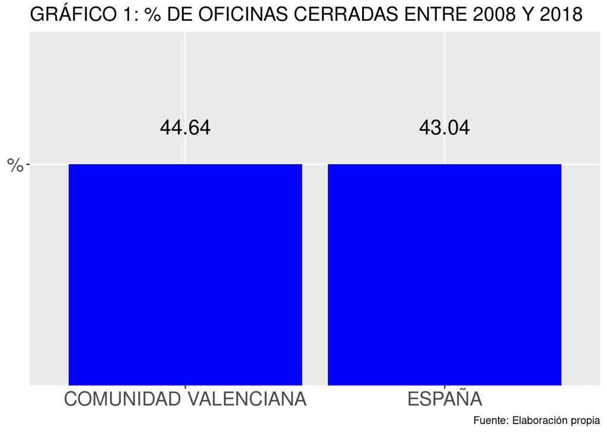

Las consecuencias de esta privación de servicios se ven amplificadas en municipios rurales de las comarcas del interior, alejadas de núcleos de población con servicios financieros lo que además de afectar a las condiciones de vida de sus habitantes condiciona enormemente cualquier tentativa de iniciativa económica.

La Generalitat, como parte de la Agenda Avant, puso en marcha una primera iniciativa contra la exclusión financiera en la Comunidad Valenciana contratado la instalación, mantenimiento y puesta en funcionamiento de servicios bancarios básicos, a través, fundamentalmente, de cajeros automáticos. Este servicio consistiría en:

- suministro e instalación de cajeros automáticos
- mantenimiento y puesta en funcionamiento
- asesoramiento financiero

Se trató de una iniciativa pionera en España impulsada desde Agenda Valenciana Antidespoblamiento. La instalación de cajeros se licitó en un procedimiento de concurrencia competitiva por parte de Presidencia adjudicándose por 7,83 millones de € para 4 años la instalación de 135 cajeros en 124 municipios.

### RED de PUNTOS LIMPIOS AVANT PARA AUTOCARAVANAS

El Consell, mediante el Decreto 27/2021, de 1 de septiembre, del presidente de la Generalitat, aprobó las bases reguladoras de las subvenciones para promocionar una red de Puntos Limpios para autocaravanas en los municipios en riesgo de despoblamiento.

Las comarcas del interior tienen un potencial turístico muy distinto al de la costa. En la Estrategia AVANT se contempla como veremos la idea estratégica de aprovechar los recursos naturales y el carácter rural; bosques y parajes que no han sido transformados como ha ocurrido en prácticamente toda la costa para ofrecer el espacio tranquilo necesario actividades de ocio y descanso.

Hasta el momento, la mayoría de las acciones en esta línea se han basado en el deporte gracias a un patrocinador fuerte y el apoyo institucional de Ayuntamientos y Mancomunidades. Un ejemplo fue el Circuito Trail de Valencia con Cajamar como esponsor.

Pero ahora la apuesta de la Administración podría resumirse en ofrecer servicios permanentes para conseguir visitas continuadas. En esta línea se ha puesto en marcha un proyecto interesante orientado al perfil de turista distinto al habitual en nuestra tierra. Desde la agenda AVANT se pensó en el turismo de autocaravanas y en crear una red de servicios asumiendo el peso de la financiación y de redacción de proyecto básico el Gobierno autonómico.

Estas áreas de servicio existen en otros lugares de Europa y su difusión puede actuar como polo de atracción para los autocaravanistas que las localizan a través de sus aplicaciones móviles. En estas áreas de servicio, los usuarios podrán repostar agua potable y vaciar las aguas grises y las aguas negras.

Las ayudas van dirigidas a financiar gastos relacionados con la ejecución de las obras de realización de Punto Limpio o Puntos Limpios AVANT, de acuerdo con el proyecto básico facilitado por la dirección general competente en materia de despoblamiento, y se realizarán en el periodo correspondiente al ejercicio presupuestario del año de la convocatoria.

Además, la Generalitat subvencionará los gastos de reparación y mejora de los Puntos Limpios AVANT existentes, para adaptarlos al proyecto básico facilitado por la dirección general competente en materia de despoblamiento.

La Dirección General de la Agenda Valenciana antidespoblamiento creará un registro en el cual se inscribirán todos los municipios de la Agenda AVANT que lo solicitan, que hayan ejecutado el proyecto básico se subvencionaran también las mejoras.

### SUBVENCIONES PARA ACTIVIDADES DESTINADAS A ATRAER RESIDENTES NUEVOS

En 2022, el gobierno valenciano aprobó mediante el Decreto 16/2022, de 18 de mayo, del president de la Generalitat, las bases reguladoras de las subvenciones destinadas a apoyar la realización de actividades ligadas a la captación de nuevas personas residentes, en los municipios beneficiarios de la línea específica del Fondo de Cooperación Municipal para la Lucha contra el Despoblamiento de los Municipios de la Comunitat Valenciana.

La ayuda va destinada a ayuntamientos y, en cuanto al criterio para determinar qué municipios pueden ser beneficiados, se ha tomado el mismo criterio que el contemplado en la ayuda de Fondo de Cooperación Municipal para la Lucha contra el Despoblamiento de los Municipios de la Comunidad Valenciana. Las actividades a subvencionar serán las relacionadas con campañas de participación ciudadana de embellecimiento del municipio, recuperación de los espacios públicos, dotación y mejora de nuevos servicios y concesión de ayudas a nuevas personas residentes.

Se trata pues de una ayuda en régimen de concurrencia competitiva, es decir, que los ayuntamientos solicitantes en cada convocatoria compiten entre ellos para ser concesionarios y también por el importe total de la ayuda. Un aspecto importante de las bases que regulan esta competencia es el recogido en la base octava del Decreto. En esta base se contempla la situación de despoblamiento mediante los indicadores que ofrece el IVE y la renta per cápita bruta

### MANTENIMIENTO Y REFORESTACIÓN DE LOS BOSQUES

En 2021, el ejecutivo valenciano por medio del Decreto 28/2021, de 1 de septiembre se aprobaba las bases reguladoras de las subvenciones destinadas a apoyar, en los municipios de la agenda AVANT.

Una nueva línea de ayudas para los municipios dedicada a la gestión forestal sostenible. Se trataba de una colaboración entre la Conselleria de Medio Ambiente y los Ayuntamientos de la Agenda AVANT para sufragar actividades de mantenimiento, recuperación y reforestación de bosques mediterráneos propiedad del municipio que no estuviesen ya gestionados por la Generalitat. Las acciones subvencionables eran de dos tipos, la “Recuperación y mejora de la gestión forestal” y la “Reforestación del bosque mediterráneo”. A efectos de lo que nos interesa, el objetivo era la generación de puestos de trabajo que permitiesen fijar población en estos municipios.

Las bases reguladoras de se aprobaron en 2021 y las órdenes de ayudas se han tramitado en los tres años consecutivos: 2021, 2022 y 2023.

### SENDEROS HOMOLOGADOS

El Plan de recuperación, transformación y resiliencia del Gobierno de España sufragado conl los Fondos Next Generation EU contempla aquellas actuaciones tendientes a la cohesión territorial y a afrontar el reto demográfico. Acogiéndose a estas ayudas, en mayo del 2023 mediante Resolución de 30 de mayo de 2023, del president de la Generalitat de 2023, se aprobaron conjuntamente las bases reguladoras y la convocatoria de ayudas para ayuntamientos municipios con riesgo de despoblamiento o mancomunidades interesadas en el mantenimiento, conservación, mejora y promoción de los senderos homologados (GR, PR y SL)[^9] existentes o la puesta en valor de estos.

Formalmente la Resolución incluía un reglamento, las bases reguladoras con vocación de permanencia que se integra en el ordenamiento y un acto administrativo, que era a convocatoria para ese año en concreto.

### LA AGENDA EN EL PLAN ESTRATÉGICO DE SUBVENCIONES

Ley 38/2003, de 17 de noviembre, general de subvenciones establece para la administración la obligación de concretar en planes estratégicos las subvenciones que programen indicando coste, fuente de financiación, plazos, objetivos y efectos perseguidos. Obligación que también recoge la la Ley 1/2015, de 6 de febrero, de la Generalitat, de hacienda pública, del sector público instrumental y de subvenciones estableciendo una duración de 3 años[^10].

De hecho, en el Plan Estratégico de Subvenciones de la Presidencia de la Generalitat para el período 2018-2020 no se incluían inicialmente algunas de las inversiones previstas en el apartado dedicado a la Agenda AVANT, como el caso de la instalación de cajeros y se procedió posteriormente a su modificación antes de la aprobación del Decreto regulador de las ayudas.

En el Plan Estratégico de subvenciones de la Presidencia de la Generalitat para el período 2021-2023 vigente tiene previstas, tras tres modificaciones el resto de los gastos de la Agenda:

- Cátedra interuniverstiaria
- Senderos Homologados
- Xarxa Punts NETS (Red de puntos limpios para autocaravanas)
- Proyectos Empresariales
- Ayudas para nuevos residentes.

*Sin rango normativo*

El mandamiento de previsión por ley en planes estratégicos responde a una imposición de estabilidad presupuestaria. Los Planes Estratégicos son un instrumento de gestión, planificación y control de la Presidencia de la Generalitat, de las políticas públicas en materia de y no tienen ningún rango normativo. La ejecución de estas previsiones dependerá de la aprobación de presupuesto anual (nótese que son plurianuales) y de la disponibilidad presupuestarias, posible cofinanciación que pueda existir de fondos de carácter finalista (Fondos Europeos o convenios con las Diputaciones sobre todo) y, evidentemente, a las restricciones que, de cara al cumplimiento de los objetivos de política económica y de estabilidad.

Los Decretos que regulan las ayudas contempladas en la Agenda AVANT ( cajeros, puntos limpios, ayudas a nuevos residentes o senderos ) que hemos explicado así como el convenio con las universidades, en cuanto a reglamentos, son independientes. No obedecen a un mandamiento legal al menos hasta la Ley 5/2023, de 13 de abril, integral de medidas contra el despoblamiento y por la equidad territorial en la Comunitat Valenciana

## LA FEDERACIÓN VALENCIANA DE MUNICIPIOS Y PROVINCIAS

La Federación Valenciana de Municipios y Provincias (FVMP) es la asociación voluntaria de los Municipios, Provincias y demás Entidades Locales para la defensa y promoción de la autonomía e intereses locales.

### OFICINA CONTRA EL DESPOBLAMIENTO

La FVMP tomó la iniciativa en el mandato 2015-2019 de crear foros de encuentro con los municipios afectados por el fenómeno de la despoblación y trabajar para sensibilizar en pro del compromiso colectivo para escuchar y atender los problemas reales a los cuales se enfrentan diariamente los municipios de interior para lo cual se constituyó el Foro de Municipios de Interior.

Tras el impulso inicial, la FVMP asumió las tareas de asesoramiento, el apoyo y la colaboración de la FVMP que aborda con soluciones claras las consecuencias que generan situaciones de debilidad para estos municipios, a través de la Oficina contra el Despoblamiento.

La Oficina contra el Despoblamiento de la FVMP cuenta con la colaboración de la Dirección General de la Agenda Valenciana Antidespoblamiento.

### PROGRAMA ITINERANT

Es un programa promovido por la FVMP que cuenta con la colaboración de la Dirección General de la Agenda Valenciana Antidespoblamiento, las Mancomunidades y los municipios AVANT. El objetivo de este programa es la movilización de profesionales itinerantes para prestar servicios básicos.

El trámite se realiza on-line.

- **Oferta profesional** Los profesionales se registran ofreciendo sus servicios,
- **Prospección de necesidades:** Los ayuntamientos demandan en base a sus necesidades y la disponibilidad de espacios públicos.
- **Contacto con profesionales inscritos:** Los técnicos de la FVMP realizarán una primera entrevista a los profesionales interesados.
- **Visita en el municipio:** Los municipios que participan en la ruta y los profesionales seleccionados, conciertan una visita in situ para ver con qué medios cuentan .
- **Asesoramiento y acompañamiento:** Los profesionales reciben de la FVMP y de los Ayuntamientos el asesoramiento necesario para implantar el servicio.

[figure not shown]

La Dirección General para la Lucha contra la Brecha Digital y la FVMP en colaboración con la Agenda Valenciana Antidespoblación desarrolló el programa de Ciudadanía Digital para promover la inclusión digital como factor de inclusión social. Este programa aprovecha las TIC para mejorar la calidad de vida de colectivos vulnerables en los municipios afectados por la despoblación al favorecer a fin de evitar la exclusión

Se trata de una formación básica para familiarizarse con los conceptos generales sobre las tecnologías de la información y de la comunicación y toman como referencia el Marco Valenciano de Competencias Digitales (DIGCOMP CV). Un aspecto importante es que dan a conocer la e-Administración.

Las actividades formativas destinadas a los municipios de AVANT son las siguientes:

- Realizar gestiones con la administración desde casa.
- Tu día a día desde el móvil
- Herramientas para crear tus propios contenidos
- Cómo utilizar la tecnología para comunicarte
- Encuentra fácilmente información en internet **

### AEDLs EN EL TERRITORIO

La FVMP convenió con LABORA Servicio Valenciano de Empleo y Formació crear una red colaborativa de AEDL´s para prestar servicio en los municipios de la Agenda AVANT. Gracias a este convenio se ha podido contratar a 12 profesionales que realizarán además de las tareas de orientación en el desarrollo económico y búsqueda de empleo o formación, la de actuar como mecanismo de conexión entre la Administración y las Instituciones públicas y los emprendedores u otros actores sociales que estén implicados en el desarrollo de algún proyecto y deseen su puesta en marcha.

### PROGRAMA REVIU

Reviu es un programa gestionado por la Federación Valenciana de Municipios y Provincias, desde septiembre del 2020 y, que cuenta con la colaboración de la Dirección General de la Agenda Valenciana Antidespoblamiento. Este es un programa que traslada familias y personas para desarrollar su proyecto de vida en un pueblo a través de oportunidades de relevo generacional, oportunidades de negocio teletrabajo y ofertas de trabajo con el objetivo de aumentar la población y luchar directamente contra el despoblamiento.

Los objetivos principales de este proyecto son impulsar y dinamizar la economía local del territorio además de asentar nuevos pobladores en el territorio rural.

**Municipios adheridos**

Todos los municipios AVANT pueden formar parte del programa REVIU

**Diferentes modalidades**

*e-Reviu*

E-Reviu es un proyecto que busca atraer gente que, por la naturaleza de su ocupación, pueden desarrollar sus funciones laborales desde casa (por cuenta de otro o cuenta propia) en municipios en riesgo de despoblamiento.

*Reviu Emprende*

Con Reviu Emprende se detectan oportunidades de negocio para que familias y personas las gestionen, convirtiéndolas en su medio de vida y que esto repercuta creando o gestionando un servicio en el pueblo

*Reviu Ocúpate*

Reviu Ocúpate se encarga de recoger ofertas de trabajo en empresas de municipios AVANT para difundirlas fuera del territorio. Estas ofertas, principalmente aquellas que se consideran de difícil cobertura, se caracterizan por respetar la estabilidad y viabilidad.

### RUTA 99

La Ruta 99 es un programa para promocionar 24 municipios de menos de 100 habitantes. Es una iniciativa se lleva a cabo mediante un convenio entre la Dirección General de la Agenda Valenciana Antidespoblación (AVANT), hoy integrada como servicio en la Dirección General de Administración Local, y la Federación Valenciana de Municipios y Provincias (FVMP).

Se trata de fomentar el turismo del interior de la Comunidad Valenciana: naturaleza, paisajes, gastronomía, deporte o patrimonio. Cada municipio ofrece un catálogo de actividades totalmente diferente. Consta de una credencial, similar al Camino de Santiago, que puedes sellar en cada localidad visitada. Se puede realizar en moto, bicicleta o a pie.

Desde la FVMP se puso en marcha la página web, la App y la credencial. Es un ejemplo sencillo de cómo las soluciones pasan por un ámbito supramunicipal y buscar las sinergias.

## NUEVO MARCO JURÍDICO. LA LEY 5/2023, de 13 de ABRIL

Este mismo año, las Cortes Valencianas han aprobado la Ley 5/2023, de 13 de abril, integral de medidas contra el despoblamiento y por la equidad territorial en la Comunitat Valenciana tiene. Veamos de forma esquemática sus principales aportaciones.

**Objetivos:**

- Establecer principios de actuación y medidas en la luchar contra el despoblamiento.
- Garantizar los servicios básicos en los municipios en riesgo de despoblamiento.
- Mejorar la calidad de vida de sus habitantes y reactivar su tejido socioeconómico.
- Favoreciendo la cohesión social y territorial
- Asegurar un desarrollo ambientalmente sostenible y territorialmente equilibrado
- Articular la gobernanza y la transversalidad de las políticas sectoriales del Consell.
- La coordinación y colaboración con otras administraciones públicas.

Podemos resumir que el interés colectivo que persigue la ley es el de buscar la equidad territorial, entendida como la garantía de igualdad de derechos para la ciudadanía valenciana

**Razones para una nueva ley integral**

Veamos a nuestro parecer cuales serían los acuerdos, instrucciones, informes tomados desde los diferentes ámbitos que motivarían una nueva ley integral valenciana en 2023

**Acuerdos y documento recientes**

*Europa*

Aunque el despoblamiento en la España del interior representa un grave problema, el reto demográfico como tal es una cuestión de primer orden en la agenda de las instituciones europeas. Podemos reseñar la conveniencia de contemplar las recientes las Conclusiones del Consejo sobre «El camino a seguir ante los retos demográficos», el informe de la Comisión sobre los efectos del cambio demográfico y su comunicación «Una Visión a largo plazo para las zonas rurales de la UE: hacia unas zonas rurales más fuertes y antes de 2040».

*España*

Como respuesta al problema del despoblamiento y a las iniciativas Europeas por parte del gobierno de la nación, podemos destacar las directrices generales de la Estrategia Nacional frente al Reto Demográfico aprobadas por Consejo de Ministros en marzo de 2019; los resultados de la Comisión Especial sobre la evolución demográfica en España del Senado, publicados en 2019; o la Declaración de Mérida de enero de 2020, de la Conferencia de Presidencias de Parlamentos Autonómicos, para trabajar conjuntamente y compartir experiencias ante los retos de «[…] la plena igualdad, la lucha contra el despoblamiento de las zonas rurales, la cohesión territorial, el envejecimiento de la población y la diversidad cultural y lingüística» o también el informe del Consejo Económico y Social de España sobre “Un medio rural vivo y sostenible» de julio de 2021.

*Comunidad Valenciana*

Un aspecto importante afecta al acuerdo de diálogo social Alcem-nos, suscrito de manera tripartita en julio de 2020, entre el Consell y las organizaciones sindicales y empresariales más representativas, que entre sus propuestas, marcó acciones para la cohesión territorial, el desarrollo rural y para revertir el fenómeno del despoblamiento.

O las conclusiones del Comité Económico y Social de la Comunitat Valenciana en su «Informe sobre el Medio Rural en la Comunitat Valenciana» aprobado en julio de 2020.

Aunque lo más importante sería el documento de la Estrategia AVANT 20-30 publicada en 2020.

## LA LEY 5/2023

La Ley 5/2023 aprobada a finales de la pasada legislatura pretende dar respuesta a las necesidades de los municipios y comarcas en riesgo de despoblación a la vez que dar oportunidades de crecimiento, pero desde una perspectiva transversal, multisectorial y coordinada como ha venido haciéndose. Con esta ley se definió un nuevo marco legal que afectaría a toda la administración autonómica, local y entidades dependientes. La ley, como hemos dicho regula algunas iniciativas que se habían puesto en marcha anteriormente.

### Principios rectores de la ley

*Transversalidad*

La perspectiva del despoblamiento se tendrá en cuenta en todas las políticas del gobierno autonómico.

*Colaboración y cooperación*

Se pretende promocionar la cooperación entre las diferentes administraciones, pero de forma especial con la administración local, no el balde, es la que en último término ejecuta u gestiona las políticas desplegadas por la Generalitat contra el despoblamiento como hemos visto. También se contempla la colaboración con el sector privado.

*La eficacia y la eficiencia*

Se entiende el resultado satisfactorio en estos términos como resultado de la coordinación entre administraciones para el empleo de los recursos. Pero no se asume el criterio “cuantitativo” sino que pretende ir “más allá” y considerar el efecto empoderador de las acciones y la calidad de vida de la ciudadanía.

*Evaluación y seguimiento*

En el necesario seguimiento continuo y su evaluación es muy importante el papel asignado al Instituto Valenciano de Estadística para obtener los indicadores adecuados.

*Participación*

Un aspecto importante al que la ley da una cobertura cuando habla de promover la participación e iniciativa social y ciudadana mediante interlocutores, agentes público y privados es la cobertura legal que da al contar con “foros permanentes de diálogos”. Es gracias al diálogo en el seno de las mancomunidades y, posteriormente, en la Comisión de Mancomunidades de la FVMP como salen las demandas de los municipios y comarcas olvidadas. En los foros de participación del municipalismo valenciano se ha podido hacer eco la voz casi apagada de la despoblación.

*Información y sensibilización*

##### Instrumentos

Una definición de los instrumentos de gobernanza y coordinación administrativa de las políticas contra el despoblamiento que dispone en base a sus competencias la Generalitat Valenciana. Algunos de estos instrumentos, anteriores a la ley, ya se han explicado en puntos anteriores como son la Comisión Interdepartamental o el fondo de financiación a los municipios. La ley prevé otros instrumentos que responden a los principios de transversalidad como el Informe de perspectiva rural, la planificación estratégica de las políticas contra el despoblamiento, las fórmulas previstas de participación de la ciudadanía y de colaboración interinstitucional, y las medidas de formación, investigación, estudio y divulgación sobre el fenómeno del despoblamiento.

Comentamos los aspectos más importantes no vistos y que introduce la ley dado su carácter transversal y aplicación general.

*Informe de perspectiva rural sobre el despoblamiento y la equidad territorial.*

Se establece la obligación de incorporar un informe de perspectiva rural sobre el despoblamiento y la equidad territorial en todo proyecto con rango de ley autonómica y los planes. El informe deberá evaluar si la ley o plan se adecua a las singularidades y recursos administrativos disponibles en los municipios de la Agenda AVANT y contar con una fase de participación con representantes de los territorios afectados.

El órgano competente en materia de políticas contra el despoblamiento, actualmente es la Dirección General de Administración Local, regulará las directrices y métodos para su elaboración.

En los presupuestos autonómicos, se considerará el impacto sobre el despoblamiento.

*Planificación estratégica.*

Se establece la obligación de elaborar una estrategia contra el desequilibrio territorial y la desigualdad de derechos que impone la despoblación. Esta estratégica deberá tener una vigencia de 10 años como mínimo.

Por otra parte, se impone la obligación de incluir en el Plan Valenciano de Estadística la elaboración de indicadores de despoblamiento en la Comunitat Valenciana, conforme a lo previsto en la normativa estadística estatal y autonómica de aplicación, fomentando el análisis estadístico y cartográfico del reto demográfico. Así como garantizar el acceso a los datos útiles para el análisis del despoblamiento y la evolución demográfica-territorial.

##### Criterios para la zonificación

Un aspecto importante de la ley es el de fijar los criterios objetivos para la, en definitiva, seleccionar qué municipios son los que deben ser atendidos de forma diferenciada. Así la ley aporta una definición de municipio en riesgo de despoblamiento, con el fin de poder enfocar las medidas transversales y sectoriales en beneficio de aquellos municipios y comarcas que padecen situaciones demográficas más graves, para lograr una mayor eficacia en las medidas, si bien con un margen de flexibilidad suficiente que permita adecuar las medidas sectoriales por razones de coherencia y equidad territorial.

Se modifican los criterios para establecer los municipios en riesgo de despoblación que introdujo la modificación de 2021 del Fondo de Cooperación Municipal para la Lucha contra el Despoblamiento de los Municipios de la Comunidad Valenciana explicados anteriormente.

La definición en base a la superación de los umbrales de los seis indicadores demográficos solo se exige el cumplimiento de cuatro.

Se mantiene el criterio de pertenecer a un área funcional con densidad de población inferior a 12,5 habitantes/Km2 y el criterio de tener una población inferior a 300 habitantes.

Añade una categoría nueva intermedia de riesgo de despoblamiento para los municipios que se encuentran delimitados en la franja intermedia definida en la Estrategia Territorial 2030 aprobada en 2011 y que no excedan de 3.000 habitantes y cumplan dos de los seis criterios basados en los indicadores demográficos.

Una vez determinados los instrumentos a utilizar y las zonas sobre las que actuar queda por determinar cuáles van a ser las acciones.

##### Servicios a asegurar

Podemos establecer un primer bloque de medidas que tienen por objeto la cohesión social, económica y territorial frente al despoblamiento. Se trata de acciones que tiene por objetivo garantizar el acceso a los servicios públicos y para la igualdad de derechos y oportunidades, en el ámbito de las políticas públicas desplegadas por el Consell que buscan una incidencia positiva en los municipios en riesgo de despoblamiento o en aquellas en las que procede una buena coordinación y colaboración con otras administraciones públicas.

Gran parte del texto de la ley en lo que se refiere a derechos prestacionales que enumera la ley son mandatos para una futura regulación, cuando no meras declaraciones de voluntades. Comentaremos lo entendemos que son acciones más claramente comprometidas o concreciones.

Acceso a la educación pública. Entre los diferentes compromisos en pro de la educación, cabría resaltar el de propiciar una adecuada rede de centros rurales agrupados y una redes de Comedores escolares en colaboración con los ayuntamientos. Aunque no estable ningún compromiso de fecha para su implantación.

Medidas relativas a la formación profesional. Los compromisos en facilitar el acceso, el contrato programa, etc… son los mismos que en resto del territorio.

Acceso a la sanidad pública. En este apartado cabría resaltar el apoyo a las farmacias comunitarias en los municipios en riesgo de despoblación. Aunque sin concretar más.

Acceso a los servicios sociales públicos. La ley prevé el desarrollo que se ha estado llevando a cabo, en base a la Ley 3/2019, de 18 de febrero, de los Servicios sociales. Se prestan gracias a la colaboración con las entidades locales pero de forma mancomunada. Se ha apostado por un Servicio supramunicipal para poder atender las diferentes necesidades con personal especializado. El problema de este modelo que es que depende económicamente de convenios de colaboración entre la Conselleria y las Diputaciones provinciales que son las que aportan “la asistencia técnica y económica” (art. 30 Ley 3/2029, de 18 de febrero), es decir, la financiación en si. De hecho, en las dos últimas legislaturas los municipios de la provincia de Alicante no tenían estos servicios sociales que enumera ahora nuestra ley por la negativa de la Diputación de Alicante a suscribir el convenio con la Generalitat.

Acceso a los servicios de justicia próxima. Quizás lo más destacable sea la apuesta por la modernización, sobre todo, tecnológica de los juzgados de paz.

Medidas para la juventud. El redactado de la ley en este apartado también es un compromiso por “desarrollo de programas específicos”. Medidas para las personas mayores. Medidas para la igualdad de género. Acceso al transporte público.

Acceso a la vivienda. Seguridad y respuesta ante las emergencias. Promoción de la cultura y el deporte. Acceso a las tecnologías de la información y la comunicación.

Acceso a servicios bancarios. Protección de los derechos de las personas consumidoras y acceso a los medios de comunicación.

##### Activación socio-económica

En un segundo bloque podríamos agrupar las medidas dirigidas a la reactivación y la diversificación socio-económicas y la promoción del empleo; constan tanto de medidas transversales de promoción, para la discriminación positiva o de incentivos fiscales, como medidas específicas de ámbito sectorial de mayor relevancia para el territorio, teniendo una especial importancia las medidas en el sector agroalimentario, en el turismo, la innovación, las energías renovables o la gestión forestal sostenible. Por último, se abordan los instrumentos de planeamiento, para su adaptación y simplificación, en consideración de las condiciones particulares de los municipios rurales en riesgo de despoblamiento.

## ESTRATEGIA AVANT 20-30

La Estrategia es un proyecto multidimensional que establece unas estrategias generales definidas mediante líneas estratégicas, así como unas propuestas concretas destinadas a combatir la despoblación de las áreas rurales valencianas. Reconoceremos en el resumen siguiente del documento, algunas de estas medidas ya aplicadas y explicadas en apartados anteriores de nuestro informe.

### FASES

#### El proceso participativo

Para la valoración y la incorporación de posibles mejoras al Documento Técnico se han convocado, con la colaboración de la FVMP, reuniones de trabajo con representantes de las siguientes organizaciones,

- Mancomunidades de municipios con despoblación.
- Grupos de Acción Local.
- Diputaciones Provinciales.
- Federación Valenciana de Municipios y Provincias.
- Sindicatos y Organizaciones Agrarias de la Comunidad Valenciana.
- Asociaciones de Empresarios en áreas caracterizadas por la despoblación.
- Colegios Profesionales.
- Federación Valenciana de Cooperativas.
- Asociaciones Rurales representativas.
- Asociaciones de ADLs de la Comunidad Valenciana
- Comisión Interdepartamental sobre la Despoblación, del Gobierno Valenciano.

#### Redacción del plan estratégico AVANT

El documento ejecutivo del Plan Estratégico recoge los siguientes puntos:

1. Un diagnóstico sintético del escenario actual del territorio afectado por la despoblación.
2. El diseño del Plan Estratégico, organizado en Líneas Estratégicas que resumiremos en el siguiente apartado.
3. Un cronograma aproximado y un avance de las partidas presupuestarias para cada Programa
4. Una propuesta, consensuada con la Dirección General AVANT, del seguimiento del desarrollo del Plan Estratégico. Recoge tanto un sistema de indicadores para dicho seguimiento, así como una estructura organizativa para llevarlo a cabo.

### RESUMEN POR ÁREAS ESTRATÉGICAS

Las Estrategia AVANT 20-30 se estructura en cuatro áreas que configuran sus líneas estratégicas y una quinta y transversal sobre Gobernanza política, que afecta a la toma de decisiones y la política que deben guiarlas.

1. Línea Estratégica Económica.
2. Línea Estratégica Medioambiental.
3. Línea Estratégica Social.
4. Línea Estratégica Cultural.
5. Línea Estratégica de Gobernanza Política.

#### Dimensión económica

Se puesta por una fiscalidad diferenciada que ayuda a la fijación de las empresas existentes y a la creación de nuevas. Destaca la idea de fomentar la economía social y el apoyo a las Oficinas Técnicas de innovación rural de las Mancomunidades.

En cuanto a sectores se centra en los tradicionales y los relacionados con los recursos propios de la zona (programas de conservación y recuperación del patrimonio cultural o recursos naturales).

En cuanto a la mejora de la conectividad considera necesaria tanto la interna basándose en el concepto introducido por la Estrategia Territorial de 2011 de capital comarcal-funcional como en ka necesidad de conectar mejor el interior de la Comunidad con el litoral

#### Dimensión medioambiental

Se propone una nueva Ley de Equilibrio Territorial atendiendo a la Estrategia Territorial del 2011 de la Comunidad Valenciana y que tenga como fin la compensación de los desequilibrios territoriales para hacer frente a las debilidades de los municipios en proceso de despoblación “merced a la prestación de servicios de municipios rurales en beneficio de los urbanos”.

Se defienden así, la idea de la subsidiariedad del entorno rural respecto al espacio urbano como eje del “Desarrollo Territorial”.

Propone medidas de conservación de los bosques, el uso de energías renovables, la calidad de las aguas, etc. aunque no acaba de desarrollar.

#### Dimensión social

En lo que la estrategia denomina “Área Social y de Comunicación y Accesibilidad”, propone llevar a cabo un Plan de Comunicación para dar a conocer el fenómeno de la despoblación-despoblamiento.

Garantizar el acceso a los servicios públicos y sociales para fijar la población.

Remarca el papel de las nuevas tecnologías como factor de desarrollo territorial.

Apuesta por el desarrollo de programas sociales dirigidos a colectivos frágiles (jóvenes, mujeres y mayores).

Se propone ejecutar acciones que directamente busquen asentar la población residente al territorio y programas de atracción de nuevos residentes.

#### Dimensión cultural

En este ámbito se defiende la estrategia de fomentar el orgullo de pertenecer al mundo rural de procedencia y también a la cultura local.

#### Dimensión de gobernanza

Destaca la coordinación entre las diversas administraciones autonómicas, y la incorporación de otras administraciones como las provinciales y mancomunidades en aras de conseguir una mayor eficacia y eficiencia.

Concretamente se propone la coordinación en las áreas de política urbanística, empleo, formación profesional, medioambiental, juventud, mayores, etc.

Coherentemente con los dos puntos anteriores, se resalta la importancia de la escala o dimensión supramunicipal que representan las mancomunidades.

Y por último anotamos la propuesta para evaluar las políticas públicas en materia de despoblación. Se propone un sistema plurianual de seguimiento de los resultados de las acciones de la Administración Autonómica en el programa Plan AVANT.

## 6. CONCLUSIONES

**Sobre el Derecho Administrativo**

Sabemos que esta parte del parte del Derecho Público, el Derecho Administrativo, se ha pretendido definir desde un punto de vista subjetivo viendo la luz desde el foco de donde nace (la Administración) como explicaba el valenciano Boquera Oliver[^11]. De igual manera se ha hecho desde un punto de vista objetivo, fijándose más en la luz en sí (los objetivos de la actividad) al entenderla por lo principal y, por último, hemos visto también una tercera interpretación al considerar el Derecho Administrativo desde un punto de vista formal y atender solo ordenamiento jurídico.

Si repasamos todo lo detallado en este informe comprobaremos que la Administración se ha ampliado con nuevas comisiones, direcciones generales, instrucciones de trabajo transversales y legislación diversa. A la vez, también ha desarrollado una mayor actividad que deberíamos valorarla no como “actos de poder” sino mejor como “tráfico administrativo” sobre todo si nos fijamos en la relevancia dada a aspectos como la difusión o la participación. No obstante, una definición del Derecho Administrativo centrada de forma exclusiva en el sujeto excluiría elementos como un convenio con las Universidades, un acuerdo tripartito como fundamento para una ley que escapa al ámbito estrictamente laboral; la colaboración de una federación de deportes autonómica o de la misma FVMP.

Por otra parte, desde una postura formal parece que las aprobaciones o rechazos de un foro como el de Foro de Municipios el Interior, el mismo acuerdo tripartito o incluso las recomendaciones de un plan estratégico quedarían al margen del Derecho Administrativo.

El informe, desde el momento que pretende mostrar toda la actividad administrativa en pro de un interés general, sobrepasa a una visión del Derecho Administrativo centrada en el sujeto como ocurriría si tomásemos las alternativas objetivistas o formales. Para definir la lucha contra el despoblamiento desde el Derecho Administrativo, este debe ser contemplado con una visión poliédrica como hemos podido comprobar.

**Sobre la continuidad de las medidas.**

Podemos pensar que es pronto para poder sacar conclusiones sobre la continuidad de la Agenda AVANT en esta etapa nueva surgida tras las elecciones autonómicas de mayo de 2023, no obstante algo sí que podemos comentar.

La estructura que un Consell obedece a unos criterios programáticos e ideológicos del equipo de gobierno. Cuando se suprime una Área, Servicio, Dirección General, Secretaría autonómica o Conselleria esta decisión responde a un cambio de valoración de las tareas que desarrollaba. Por lo tanto, es inevitable que aparezca cierta preocupación ante la supresión de la Dirección General de la Agenda AVANT y su conversión en un servicio de la Dirección General de Administración Local. La supresión de la Dirección General de Estadística o el hecho que aún no se haya nombrado al Director Valenciano del Instituto tampoco son tranquilizadores.

# 6. LEGISLACIÓN

- DECRETO 182/2018, de 10 de octubre, del Consell, por el que se regula la línea específica del Fondo de Cooperación Municipal para la Lucha contra el despoblamiento de los Municipios de la Comunitat Valenciana.
- DECRETO 1/2020, de 6 de febrero, del presidente de la Generalitat, por el que se aprueban las bases reguladoras de las subvenciones destinadas a incentivar y fomentar la prestación de servicios bancarios básicos, a través, principalmente, de la instalación, mantenimiento y puesta en funcionamiento de cajeros automáticos, en determinados municipios y núcleos de población en el ámbito territorial de la Comunitat Valenciana.
- DECRETO 16/2022, de 18 de mayo, del president de la Generalitat, por el que se aprueban las bases reguladoras de las subvenciones destinadas a apoyar la realización de actividades ligadas a la captación de nuevas personas residentes, en los municipios beneficiarios de la línea específica del Fondo de Cooperación Municipal para la Lucha contra el Despoblamiento de los Municipios de la Comunitat Valenciana.
- DECRETO 169/2020, de 30 de octubre, del Consell, de aprobación del Reglamento orgánico y funcional de la Presidencia de la Generalitat.
- DECRETO 182/2018, de 10 de octubre, del Consell, por el que se regula la línea específica del Fondo de Cooperación Municipal para la Lucha contra el Despoblamiento de los Municipios de la Comunitat Valenciana.
- DECRETO 21/2020, de 29 de diciembre, del president de la Generalitat, que modifica el Decreto 1/2020, de 6 de febrero, del presidente de la Generalitat, por el que se aprueban las bases reguladoras de las subvenciones destinadas a incentivar y fomentar la prestación de servicios bancarios básicos, a través, principalmente, de la instalación, mantenimiento y puesta en funcionamiento de cajeros automáticos, en determinados municipios y núcleos de población en el ámbito territorial de la Comunitat Valenciana.
- DECRETO 27/2021, de 1 de septiembre, del presidente de la Generalitat, por el cual se aprueban las bases reguladoras de las subvenciones destinadas a la promoción y fomento de la red de Puntos Limpios AVANT en los municipios en riesgo de despoblamiento en el ámbito de la Comunidad Valenciana.
- DECRETO 28/2021, de 1 de septiembre, del presidente de la Generalitat, por el que se aprueban las bases reguladoras de las subvenciones destinadas a apoyar, en los municipios de la agenda AVANT, la realización de actividades de mantenimiento, recuperación y reforestación de los bosques mediterráneos de sus términos municipales.
- DECRETO 58/2017, de 28 de abril, del Consell, por el que se crea la Comisión Interdepartamental para la Lucha contra el Despoblamiento de los Municipios Valencianos.
- DECRETO 89/2021, de 2 de julio, del Consell, de modificación del Decreto 182/2018, de 10 de octubre, del Consell, por el que se regula la línea específica del Fondo de

Cooperación Municipal para la Lucha contra el Despoblamiento de los Municipios de la Comunitat Valenciana.

- Directiva 2014/92/UE del Parlamento Europeo y el Consejo, de 23 de julio de 2014, sobre la comparabilidad de las comisiones conexas a las cuentas de pago, el traslado de cuentas de pago y el acceso a cuentas de pago básicas.
- Estatuto de Autonomía de la Comunidad Valenciana.
- Ley 2/1988, de 17 de mayo, de creación del Instituto Valenciano de Estadística.
- Ley 5/1990, de 7 de junio, de estadística de la Comunidad Valenciana.
- Ley 5/2021, de 5 de noviembre, reguladora del Fondo de Cooperación Municipal de los Municipios y Entidades Locales Menores de la Comunitat Valenciana.
- Ley 5/2023, de 13 de abril, integral de medidas contra el despoblamiento y por la equidad territorial en la Comunitat Valenciana.
- RESOLUCIÓN de 14 de abril de 2023, de la Presidencia de la Generalitat, por la que se convocan subvenciones destinadas a la promoción y fomento de la red de Punts Nets AVANT en los municipios en riesgo de despoblamiento en el ámbito de la Comunitat Valenciana.
- RESOLUCIÓN de 15 de febrero de 2023, de la Presidencia de la Generalitat, por la que se convocan subvenciones destinadas a apoyar, en los municipios de la Agenda AVANT, la realización de actividades de mantenimiento, recuperación y reforestación de los bosques mediterráneos de sus términos municipales.
- RESOLUCIÓN de 15 de junio de 2023, de la Presidencia de la Generalitat, de concesión de subvenciones destinadas a la promoción y el fomento de la red de Punts Nets AVANT en los municipios en riesgo de despoblamiento en el ámbito de la Comunitat Valenciana.
- RESOLUCIÓN de 30 de mayo de 2023, del president de la Generalitat, por la que se establecen las bases reguladoras y se aprueba la convocatoria de ayudas dirigidas a financiar el mantenimiento, conservación, mejora y promoción de los senderos homologados (GR®, PR® y SL®) existentes, en municipios con riesgo de despoblamiento y en otras entidades locales de las cuales forman parte municipios con riesgo de despoblamiento, en el ámbito de la Comunitat Valenciana, en el marco del Plan de recuperación, transformación y resiliencia.
- RESOLUCIÓN de 9 de mayo de 2019, del director general de Relaciones con Les Corts, por la que se publica el Convenio marco entre la Generalitat, a través de la Presidencia, la Universitat de València - Estudi General, la Universitat Politècnica de València, la Universitat Jaume I de Castelló y la Universidad de Alicante, para la creación de la Cátedra Avant.

# 7. OTROS RECURSOS

- Agenda AVANT https://avant.gva.es/
- Estrategia AVANT 20-30 “Plan Estratégico valenciano antidespoblamiento” https://avant.gva.es/documents/173292247/173293721/ESTRATEGIA\_AVANT\_20-30\_c.pdf/9f4c4e85-4248-4d1f-955c-b2ae0669fa7b
- Estrategia Territorial 2030 de la CV

  https://mediambient.gva.es/es/web/planificacion-territorial-e-infraestructura-verde/libro-digital-77497
- Instituto Valenciano de Estadística https://pegv.gva.es/es/
- Instituto Cartográfico Valenciano https://visor.gva.es/visor/
- Maratón de Montaña Valencia https://mamova.es
- Planes estratégicos de subvenciones.

  https://gvaoberta.gva.es/es/plans-estrategics-de-subvencions#presidencia
- Ruta99. https://ruta99.gva.es
[^1]: La estrategia territorial de la comunidad valenciana. La Estrategia Territorial de la Comunidad Valenciana se aprobó en 2011. Es el instrumento que define el modelo territorial de la Comunidad Valenciana a largo plazo Integra las políticas sectoriales con proyección territorial y establece directrices de planificación y gestión para el suelo a nivel subregional.
[^2]: El Decreto 182/2018, de 10 de octubre, del Consell crea el Fondo de Cooperación Municipal para la Lucha contra el Despoblamiento.
[^3]: La normativa estadística básica valenciana contempla el cumplimiento del PVE y se desarrolla en Programas Anuales que son las herramientas de planificación a corto plazo que distribuyen temporalmente las actividades estadísticas.
[^4]: El articulo 201 Ley 8/2010, de 23 de junio, de régimen local de la Comunidad Valenciana de acuerdo con el artículo 64.3 del Estatuto de Autonomía establece la creación del Fondo de Cooperación Municipal
[^5]: En otras autonomías como Andalucía la asignación estaba condicionada parcialmente y existían fórmulas polinómicas para el cálculo de importe correspondiente a cada municipio.
[^6]: Acuerdo del Foro de Municipios de Interior (FVMP) a favor de los criterios incluidos en el nuevo decreto https://www.fvmp.es/wp-content/uploads/2021/03/nota-fmi-criterios.pdf
[^7]: Las Áreas Funcionales son ámbitos territoriales intermedios entre el espacio regional y el municipal, definidos en la Ley de Ordenación del Territorio y Protección del Paisaje como los adecuados para la gestión y planificación territorial supramunicipal, capaces de articular el territorio de manera efectiva y delimitadas de acuerdo con criterios que reflejan la funcionalidad del territorio, tales como los desplazamientos obligados y no obligados, los procesos de expansión urbana, la optimización de las áreas de prestación de servicios supramunicipales y los corredores de transporte público
[^8]: Tras el cambio de gobierno en 2023, esta Dirección General ha sido suprimida y la Agencia AVANT se integra como un Servicio en la Dirección General de Administración Local también dependiente de Presidencia.
[^9]: Gran Recorrido, Pequeño Recorrido y Sendero Local
[^10]: Los planes Estratégicos de subvenciones de la Presidencia de la Generalitat trianuales se han modificado has tres veces. Véase en: https://gvaoberta.gva.es/es/plans-estrategics-de-subvencions#presidencia
[^11]: BOQUERA OLIVER, J.M, “Criterio conceptual del Derecho Administrativo”, cit, pp. 123, 124 [ref1]: Aspose.Words.9daf951d-86a8-4dfc-b730-879fe787d516.001.png